# Udacity Machine Learning NanoDegree Capstone Project

# mostafa hamed

Wearable devices have become extremely popular in recent years for tracking user activity. These small devices use movement and motion data obtained through internal sensors that give insights into the various types of activities that are being performed by the user. This data exploration Notebook is to better understand the preprocessed version of the dataset, it's features & targets, and how best to proceed with fitting a model to it.

### Smartphone-Based Recognition of Human Activities and Postural Transitions Data Set

*Note: This data set was obtained from the UCI Machine Learning Repository found here: http://archive.ics.uci.edu/ml/datasets/Smartphone-Based+Recognition+of+Human+Activities+and+Postural+Transitions*

```python
from google.colab import drive
drive.mount('/content/drive')
```

```python
import pandas as pd
import seaborn as sns
import matplotlib.pyplot as plt
from mpl_toolkits.mplot3d import Axes3D

#sklearn imports
from sklearn.decomposition import PCA
from sklearn.naive_bayes import GaussianNB
from sklearn.metrics import accuracy_score, make_scorer
from sklearn.svm import SVC, LinearSVC
from sklearn.model_selection import GridSearchCV

# inline graphs in Jupyter Notebook
%matplotlib inline
```

```python
with open('/content/drive/My Drive/Colab Notebooks/hapt-data (1)/features.txt','r') as f:
    features = [line.strip() for line in f]
```

```python
X_train = pd.read_csv('/content/drive/My Drive/Colab Notebooks/hapt-data/Train/X_train.txt', sep=' ', header=None)
X_train.columns= features
X_train.head()
```

|  | tBodyAcc-Mean-1 | tBodyAcc-Mean-2 | tBodyAcc-Mean-3 | tBodyAcc-STD-1 | tBodyAcc-STD-2 | tBodyAcc-STD-3 | tBodyAcc-Mad-1 | tBodyAcc-Mad-2 | tBodyAcc-Mad-3 | tBodyAcc-Max-1 | tBodyAcc-Max-2 | tBodyAcc-Max-3 | tBodyAcc-Min-1 | tBodyAcc-Min-2 | tBodyAcc-Min-3 | tBodyAcc-SMA-1 | tBodyAcc-Energy-1 | tBodyAcc-Energy-2 | tBodyAcc-Energy-3 | tBodyAcc-IQR-1 | tBodyAcc-IQR-2 | tBodyAcc-IQR-3 | tBodyAcc-ropy-1 | tBodyAcc-ropy-1 | tBodyAcc-ropy-1 | tBodyAcc-ARCoeff-1 | tBodyAcc-ARCoeff-2 | tBodyAcc-ARCoeff-3 | tBodyAcc-ARCoeff-4 | … |
| --- | --- | --- | --- | --- | --- | --- | --- | --- | --- | --- | --- | --- | --- | --- | --- | --- | --- | --- | --- | --- | --- | --- | --- | --- | --- | --- | --- | --- | --- | --- |
| 0 | 0.043580 | -0.005970 | -0.035054 | -0.995381 | -0.988366 | -0.937382 | -0.995007 | -0.988816 | -0.953325 | -0.794796 | -0.744893 | -0.648447 | 0.841796 | 0.708440 | 0.651716 | -0.975752 | -0.999950 | -0.999888 | -0.998014 | -0.993999 | -0.991980 | -0.970970 | -0.547095 | -0.700974 | -0.622697 | 0.921884 | -0.719483 | 0.342168 | -0.161318 | … |
| 1 | 0.039480 | -0.002131 | -0.029067 | -0.998348 | -0.982945 | -0.971273 | -0.998702 | -0.983315 | -0.974000 | -0.802537 | -0.736338 | -0.712415 | 0.838758 | 0.708440 | 0.659340 | -0.987427 | -0.999993 | -0.999826 | -0.999411 | -0.998918 | -0.985482 | -0.973481 | -0.781973 | -0.534604 | -0.593165 | 0.607435 | -0.266783 | 0.275882 | 0.200417 | … |
| 2 | 0.039978 | -0.005153 | -0.022651 | -0.995482 | -0.977314 | -0.984760 | -0.996415 | -0.975835 | -0.985973 | -0.798477 | -0.736338 | -0.712415 | 0.834002 | 0.705008 | 0.674551 | -0.988528 | -0.999972 | -0.999719 | -0.999803 | -0.996898 | -0.976781 | -0.986754 | -0.688176 | -0.520514 | -0.593165 | 0.272262 | -0.056424 | 0.322283 | -0.273292 | … |
| 3 | 0.039785 | -0.011809 | -0.028916 | -0.996194 | -0.988569 | -0.993256 | -0.996994 | -0.988526 | -0.993135 | -0.798477 | -0.752778 | -0.722186 | 0.834002 | 0.705008 | 0.673208 | -0.990389 | -0.999978 | -0.999783 | -0.999815 | -0.996949 | -0.989437 | -0.992440 | -0.715103 | -0.860988 | -0.916429 | 0.062816 | 0.082940 | 0.200566 | -0.378262 | … |
| 4 | 0.038758 | -0.002289 | -0.023863 | -0.998241 | -0.986774 | -0.993115 | -0.998216 | -0.986479 | -0.993825 | -0.801982 | -0.746505 | -0.717858 | 0.838581 | 0.705854 | 0.673208 | -0.995057 | -0.999992 | -0.999882 | -0.999908 | -0.997772 | -0.987726 | -0.995109 | -0.836774 | -0.589200 | -0.773771 | 0.312105 | -0.095254 | 0.194399 | -0.007998 | … |

5 rows × 561 columns

```python
# load the testing set features
X_test = pd.read_csv('/content/drive/My Drive/Colab Notebooks/hapt-data/Test/X_test.txt', sep=' ', header=None)
X_test.columns = features
X_test.head()
```

|  | tBodyAcc-Mean-1 | tBodyAcc-Mean-2 | tBodyAcc-Mean-3 | tBodyAcc-STD-1 | tBodyAcc-STD-2 | tBodyAcc-STD-3 | tBodyAcc-Mad-1 | tBodyAcc-Mad-2 | tBodyAcc-Mad-3 | tBodyAcc-Max-1 | tBodyAcc-Max-2 | tBodyAcc-Max-3 | tBodyAcc-Min-1 | tBodyAcc-Min-2 | tBodyAcc-Min-3 | tBodyAcc-SMA-1 | tBodyAcc-Energy-1 | tBodyAcc-Energy-2 | tBodyAcc-Energy-3 | tBodyAcc-IQR-1 | tBodyAcc-IQR-2 | tBodyAcc-IQR-3 | tBodyAcc-ropy-1 | tBodyAcc-ropy-1 | tBodyAcc-ropy-1 | tBodyAcc-ARCoeff-1 | tBodyAcc-ARCoeff-2 | tBodyAcc-ARCoeff-3 | tBodyAcc-ARCoeff-4 | … |
| --- | --- | --- | --- | --- | --- | --- | --- | --- | --- | --- | --- | --- | --- | --- | --- | --- | --- | --- | --- | --- | --- | --- | --- | --- | --- | --- | --- | --- | --- | --- |
| 0 | 0.030914 | -0.008927 | 0.040382 | -0.938504 | -0.944626 | -0.759334 | -0.952398 | -0.950281 | -0.802483 | -0.757099 | -0.733398 | -0.407960 | 0.728511 | 0.658266 | 0.629169 | -0.913306 | -0.997966 | -0.998683 | -0.975818 | -0.975440 | -0.966793 | -0.914396 | -0.363822 | -0.420897 | 0.181772 | 0.517928 | -0.403636 | 0.449325 | -0.147545 | … |
| 1 | 0.042548 | 0.001079 | -0.026236 | -0.975516 | -0.977502 | -0.960146 | -0.986694 | -0.978983 | -0.966820 | -0.757099 | -0.733398 | -0.701699 | 0.770927 | 0.706301 | 0.635732 | -0.978295 | -0.999618 | -0.999708 | -0.999158 | -0.993775 | -0.982664 | -0.974733 | -0.466563 | -0.392219 | -0.435565 | 0.504355 | -0.117122 | 0.062621 | 0.188184 | … |
| 2 | 0.038297 | -0.011660 | -0.025643 | -0.993922 | -0.979215 | -0.973030 | -0.994298 | -0.980535 | -0.977508 | -0.799005 | -0.745911 | -0.695737 | 0.837921 | 0.690520 | 0.659163 | -0.983764 | -0.999959 | -0.999645 | -0.999527 | -0.993224 | -0.983084 | -0.981887 | -0.707815 | -0.716036 | -0.560652 | 0.241698 | -0.081234 | 0.055641 | 0.103205 | … |
| 3 | 0.036205 | -0.018148 | -0.025240 | -0.994845 | -0.981534 | -0.976175 | -0.995169 | -0.983020 | -0.980785 | -0.798401 | -0.745911 | -0.695737 | 0.837921 | 0.690520 | 0.659163 | -0.982082 | -0.999958 | -0.999445 | -0.999605 | -0.995004 | -0.986065 | -0.984399 | -0.808499 | -0.906026 | -0.576886 | 0.174917 | -0.026176 | 0.056952 | 0.062357 | … |
| 4 | 0.038034 | -0.013437 | -0.032899 | -0.993955 | -0.977493 | -0.984290 | -0.994006 | -0.977354 | -0.985899 | -0.798401 | -0.739013 | -0.718886 | 0.838651 | 0.693346 | 0.665950 | -0.982697 | -0.999958 | -0.999559 | -0.999565 | -0.993266 | -0.978262 | -0.987548 | -0.686907 | -0.757736 | -0.809791 | 0.116403 | -0.006796 | -0.001722 | 0.210691 | … |

5 rows × 561 columns

```python
import numpy as np
print('The training set has {} examples'.format(len(X_train)))
print('The testing set has  {} examples'.format(len(X_test)))
print('')
print('The percentage of test to total examples is {:.2f}%'.format(len(X_test) / float(len(X_test) + len(X_train)) * 100) )
```

```
The training set has 7767 examples
The testing set has  3162 examples

The percentage of test to total examples is 28.93%
```

```python
with open('/content/drive/My Drive/Colab Notebooks/hapt-data/activity_labels.txt','r') as f:
    activities = [line.strip() for line in f]
activity_dict ={}

for activity in activities:
    if int(activity[0:2]) <= 9:
        activity_dict[activity[0]] = activity[2:]
        print('Activity #{} corresponds to {}'.format(activity[0] + ' ', activity[2:]))
    else:
        activity_dict[activity[0:2]] = activity[3:]
        print('Activity #{} corresponds to {}'.format(activity[0:2] + ' ', activity[3:]))
```

```
Activity #1  corresponds to WALKING
Activity #2  corresponds to WALKING_UPSTAIRS
Activity #3  corresponds to WALKING_DOWNSTAIRS
Activity #4  corresponds to SITTING
Activity #5  corresponds to STANDING
Activity #6  corresponds to LAYING
Activity #7  corresponds to STAND_TO_SIT
Activity #8  corresponds to SIT_TO_STAND
Activity #9  corresponds to SIT_TO_LIE
Activity #10  corresponds to LIE_TO_SIT
Activity #11  corresponds to STAND_TO_LIE
Activity #12  corresponds to LIE_TO_STAND
```

```python
# load the training set targets
y_train = pd.read_csv('/content/drive/My Drive/Colab Notebooks/hapt-data/Train/y_train.txt', sep=' ', header=None)
y_train.columns = ['activity']
```

```python
# load the testing set targets
y_test = pd.read_csv('/content/drive/My Drive/Colab Notebooks/hapt-data/Test/y_test.txt', sep=' ', header=None)
y_test.columns = ['activity']
```

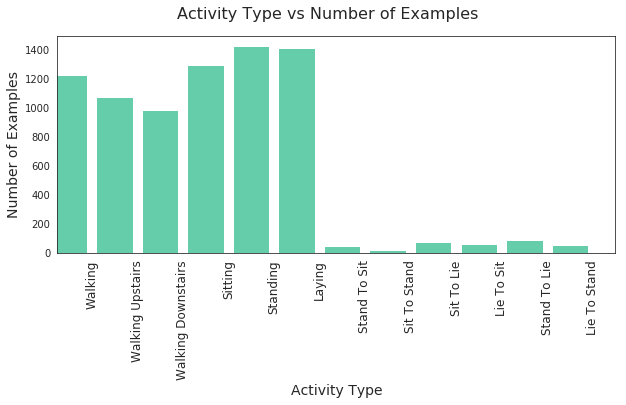

```python
import numpy as np
import re

activity_type, counts = np.unique(y_train.activity.values, return_counts=True)

sns.set_style('white')
plt.figure(figsize=(10, 4))

plt.bar(activity_type, counts, color='mediumaquamarine')
plt.suptitle('Activity Type vs Number of Examples', fontsize=16)
plt.xticks([(x + 1.5) for x in range(len(counts) + 1)],
           [re.sub('[^A-Za-z\s]', ' ', x.split()[1]).title() for x in activities],
           rotation=90, fontsize=12)
plt.xlabel('Activity Type', fontsize=14)
plt.xlim([0.75, 13])
plt.ylabel('Number of Examples', fontsize=14)

plt.show()
```

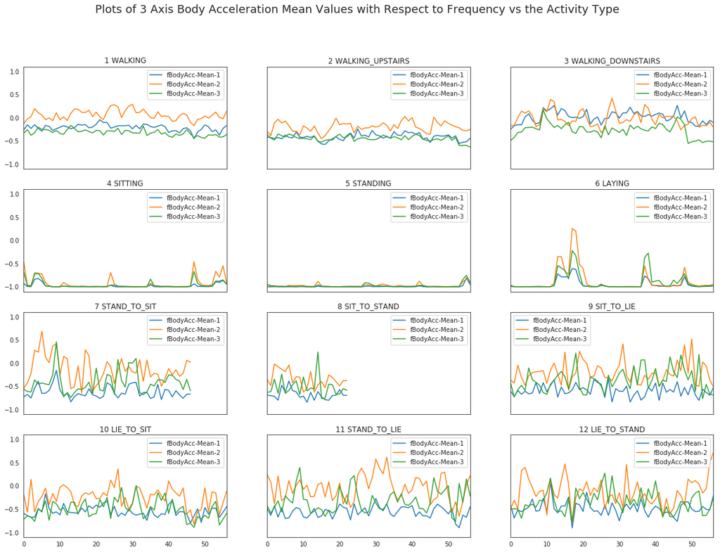

```python
# plots of the variables
def plot_variables_vs_activity(variables, title, sharex=True, sharey=True):
    fig, axes = plt.subplots(nrows=4, ncols=3, sharey=sharey, sharex=sharex)
    fig.set_size_inches(20, 14)

    # give the plot a title
    plt.suptitle(title, fontsize=18)

    # initialize locations.
    x_location = 0
    y_location = 0

    for activity_number in range(1, len(counts) + 1):
        # plot the current activity
        X_train[y_train['activity'] == activity_number][variables].plot(
            use_index=False, ax=axes[y_location, x_location])

        # set the activity title
        axes[y_location, x_location].set_title(activities[activity_number - 1])

        # update the x & y locations for subplots
        if x_location < 2:
            x_location += 1
        else:
            x_location = 0
            y_location += 1

variables = ['fBodyAcc-Mean-1', 'fBodyAcc-Mean-2', 'fBodyAcc-Mean-3']
title = 'Plots of 3 Axis Body Acceleration Mean Values with Respect to Frequency vs the Activity Type'

plot_variables_vs_activity(variables, title)
```

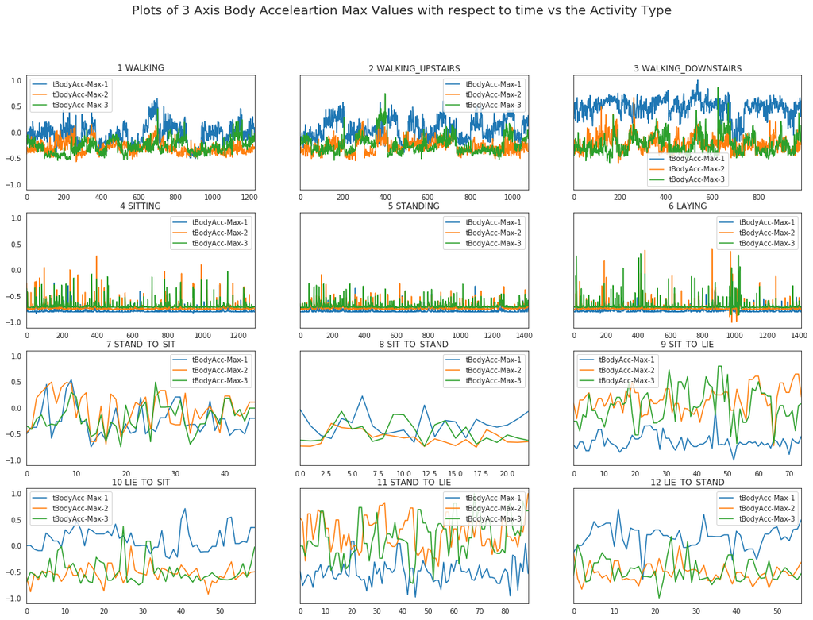

```python
# t body acc max value
variables = ['tBodyAcc-Max-1', 'tBodyAcc-Max-2', 'tBodyAcc-Max-3']
title = 'Plots of 3 Axis Body Acceleartion Max Values with respect to time vs the Activity Type'

plot_variables_vs_activity(variables, title, sharex=False)
```

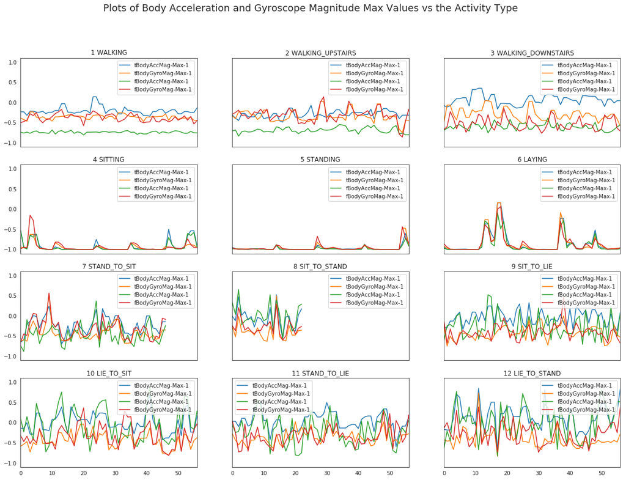

```python
# tbody Acc Mag Max, tbody Gyro Mag Max
variables = ['tBodyAccMag-Max-1', 'tBodyGyroMag-Max-1', 'fBodyAccMag-Max-1', 'fBodyGyroMag-Max-1']
title = 'Plots of Body Acceleration and Gyroscope Magnitude Max Values vs the Activity Type'

plot_variables_vs_activity(variables, title)
```

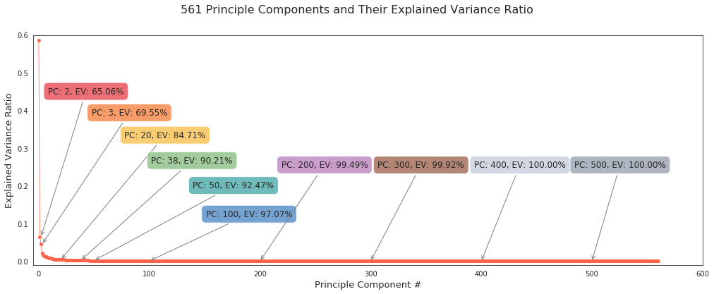

```python
# Full PCA of same shape to see how much variance is captured by each PCA
pca = PCA(n_components = X_train.shape[1], whiten=True)

pca.fit(X_train)

#plot PCA component vs it's explained Variance
plt.figure(figsize=(17, 6))

# plot limits
plt.xlim([-5, 600])
plt.ylim([-0.01, 0.6])

# plot priniciple components
plt.scatter([x for x in range(X_train.shape[1])], pca.explained_variance_ratio_, s=15, color='tomato')
plt.plot([x for x in range(X_train.shape[1])], pca.explained_variance_ratio_, '-', c='tomato', linewidth=0.75)

# a few annotations
colors = ['#EC5f67', '#F99157', '#FAC863', '#99C794', '#5FB3B3',
          '#6699CC', '#C594C5', '#AB7967', '#CDD3DE', '#A7ADBA']

# location tuples
locs = [(10, 200), (70, 180), (90, 170), (100, 135), (140, 100),
       (80, 60), (30, 130), (10, 130), (-10, 130), (-25, 130)]

# points to mark
points = [2, 3, 20, 38, 50, 100, 200, 300, 400, 500]

for i, anno in enumerate(points):
    plt.annotate('PC: {}, EV: {:.2f}%'.format(anno, np.sum(pca.explained_variance_ratio_[:anno]) * 100),
                xy = (anno, pca.explained_variance_ratio_[anno - 1]), xytext = locs[i],
                textcoords = 'offset points', ha = 'left', va = 'bottom', fontsize=12,
                bbox = dict(boxstyle = 'round,pad=0.5', fc = colors[i], alpha = 0.9),
                arrowprops = dict(arrowstyle = '->', connectionstyle = 'arc3,rad=0', linewidth=1, color='grey'))

# set up plot annotations
plt.suptitle("561 Principle Components and Their Explained Variance Ratio", fontsize=16)
plt.xlabel('Principle Component #', fontsize=13)
plt.ylabel('Explained Variance Ratio', fontsize=13)

plt.show()
```

```python
# 2 & 3 component PCA as these are still in a realm to plot and visualize
print('{:.2f}% of the variance in the data can be explained by  2 prinicple components'.format(
    (pca.explained_variance_ratio_[0] + pca.explained_variance_ratio_[1]) * 100) )
print('{:.2f}% of the variance in the data can be explained by  3 prinicple components'.format(
    (pca.explained_variance_ratio_[0] + pca.explained_variance_ratio_[1] +
    pca.explained_variance_ratio_[2]) * 100) )

# how many PCA's do we need to include to capture 90% of the explained varience
variance_total = 0
for i, value in enumerate(pca.explained_variance_ratio_):
    variance_total += value
    if variance_total >= .9:  # stop at 90%
        print('{:.2f}% of the variance in the data can be explained by {} prinicple components'.format(
            variance_total * 100, i + 1) )
        break #exit loop
```

```
65.06% of the variance in the data can be explained by  2 prinicple components
69.55% of the variance in the data can be explained by  3 prinicple components
90.21% of the variance in the data can be explained by 38 prinicple components
```

```python
# Although PCA for 3 components only captures ~70% of the explained variance
# for visualization and understanding purposes a PCA reduction to 2 was performed
from sklearn.decomposition import PCA
pca_2 = PCA(n_components = 2, whiten=True)

pca_2.fit(X_train)

# Print the components and the amount of variance in the data contained in each dimension
print(pca_2.components_)
print(pca_2.explained_variance_ratio_)
```

```
[[-0.00015235  0.00013133  0.00022622 ... -0.03660483  0.02668244
   0.02207401]
 [ 0.00125588  0.00270589  0.00196012 ...  0.05143451 -0.02052715
  -0.02527979]]
[0.58635593 0.06425612]
```

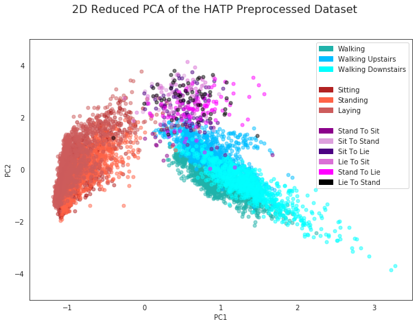

```python
# import mpatches for legend creation
import matplotlib.patches as mpatches

# set seaborn styling to white
sns.set_style('white')

# activites removed numbers and title cased
cleaned_activities = [re.sub('[^A-Za-z\s]', ' ', x.split()[1]).title() for x in activities]

# Inital plot of Activity 1
ax = pd.DataFrame(pca_2.transform(X_train[y_train['activity'] == 1]), columns=['PC1', 'PC2']).plot(
        kind='scatter', x='PC1', y='PC2', figsize=(10, 7), s=25.0,
        alpha=0.5, color='lightseagreen', ylim=[-5, 5], xlim=[-1.5, 3.5])

# colors
colors = ['lightseagreen', 'deepskyblue', 'cyan', 'firebrick', 'tomato', 'indianred',
          'darkmagenta', 'plum', 'indigo', 'orchid', 'fuchsia', 'black']

for i, color in enumerate(colors[1:]):
    pd.DataFrame(pca_2.transform(X_train[y_train['activity'] == (i + 2)]), columns=['PC1', 'PC2']).plot(
            kind='scatter', x='PC1', y='PC2', figsize=(10, 7), s=25.0,
            alpha=0.5, color=color, ylim=[-5, 5], xlim=[-1.5, 3.5], ax=ax)


colors_modified = list(colors)
colors_modified.insert(3, 'white')
cleaned_activities.insert(3, '')
colors_modified.insert(7, 'white')
cleaned_activities.insert(7, '')

mpat_list = []
for i, color in enumerate(colors_modified):
    mpat_list.append(mpatches.Patch(color=color, label=cleaned_activities[i]))

plt.suptitle('2D Reduced PCA of the HATP Preprocessed Dataset', fontsize=16)
plt.legend(handles = mpat_list)

plt.show()
```

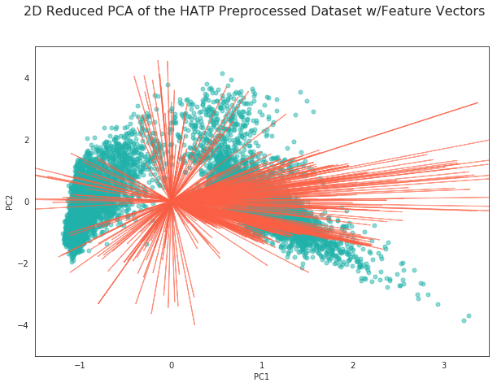

```python
# plot 2d PCA with Feature vectors
ax = pd.DataFrame(pca_2.transform(X_train), columns=['PC1', 'PC2']).plot(
        kind='scatter', x='PC1', y='PC2', figsize=(10, 7), s=25.0,
        alpha=0.5, color='lightseagreen', ylim=[-5, 5], xlim=[-1.5, 3.5])
plt.suptitle('2D Reduced PCA of the HATP Preprocessed Dataset w/Feature Vectors', fontsize=16)

for i, (pc1, pc2) in enumerate(zip(pca.components_[0], pca.components_[1])):
            ax.arrow(0, 0, pc1*30, pc2*30, width=0.003, fc='firebrick', ec='tomato', alpha=0.6)
            #ax.annotate(X_train.columns[i], (pc1*20, pc2*20), size=5)

plt.show()
```

```python
# Although PCA for 3 components only captures ~70% of the explained variance
# it's still in a space that can be iniutively understood and visualized.
from sklearn.decomposition import PCA
pca_3 = PCA(n_components = 3, whiten=True)

pca_3.fit(X_train)

# Print the components and the amount of variance in the data contained in each dimension
print(pca_3.components_)
print(pca_3.explained_variance_ratio_)
```

```
[[-1.52350723e-04  1.31333804e-04  2.26220409e-04 ... -3.66048330e-02
   2.66824414e-02  2.20740051e-02]
 [ 1.25587754e-03  2.70588961e-03  1.96011613e-03 ...  5.14345121e-02
  -2.05271475e-02 -2.52797908e-02]
 [ 6.95889917e-03 -4.84213150e-03 -3.60302332e-03 ...  2.80486574e-01
  -1.36272838e-01 -1.09363381e-01]]
[0.58635593 0.06425612 0.04489017]
```

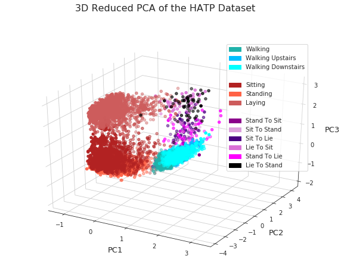

```python
# plot 3-dimensional PCA
pca_3d = plt.figure(figsize=(10, 7)).gca(projection='3d')

# iterate through color and activity type
for i, color in enumerate(colors):
    pca_3d_df = pd.DataFrame(pca_3.transform(X_train[y_train['activity'] == (i + 1)]), columns=['PC1', 'PC2', 'PC3'])
    pca_3d.scatter(pca_3d_df['PC1'], pca_3d_df['PC2'], pca_3d_df['PC3'], c=color)

# set labels and titles
plt.suptitle('3D Reduced PCA of the HATP Dataset', fontsize=16)
pca_3d.set_xlabel('PC1', fontsize=13, labelpad=10)
pca_3d.set_ylabel('PC2', fontsize=13, labelpad=10)
pca_3d.set_zlabel('PC3', fontsize=13, labelpad=10)

# set pane colors
pca_3d.w_xaxis.set_pane_color((1.0, 1.0, 1.0, 1.0))
pca_3d.w_yaxis.set_pane_color((1.0, 1.0, 1.0, 1.0))
pca_3d.w_zaxis.set_pane_color((1.0, 1.0, 1.0, 1.0))

# set grid colors
pca_3d.w_xaxis.gridlines.set_lw(1.0)
pca_3d.w_yaxis.gridlines.set_lw(1.0)
pca_3d.w_zaxis.gridlines.set_lw(1.0)

# add legend
plt.legend(handles = mpat_list, bbox_to_anchor=(0.92, 0.97))

plt.show()
```

```python
# Training Function
import time

# a function to keep track of training time
# always a good metric to keep track of for choosing between similar performing models
def train_classifier(clf, X_train, y_train):
    print ("Training {}...".format(clf.__class__.__name__))

    # time and training of the classifier
    start = time.time()
    clf.fit(X_train, y_train)
    end = time.time()

    total_training_time = end - start
    print ("Done!\nTraining time (secs): {:.3f}".format(total_training_time))

    return total_training_time # return to keep track
```

```python
# Plotting functions
tick_activities = [re.sub('[^A-Za-z\s]', ' ', x)[2:].title() for x in activities]

# Simplified confusion matrix array
def normalize_cm(confusion_matrix):
    return (confusion_matrix.astype('float') /
            confusion_matrix.sum(axis=1)[:, np.newaxis])

def plot_confusion_matricies(training_cm, test_cm, title, questionable_annot_colors=None):

    # setup sub axes
    fig, axes = plt.subplots(nrows=1, ncols=2, sharex=True, sharey=True)
    fig.set_size_inches(20, 7) # Plot figure Size

    # Normalize the confusion matricies by row (i.e by the number of samples in each class)
    training_cm_normalized = normalize_cm(training_cm)
    test_cm_normalized = normalize_cm(test_cm)

    # plot
    sns.heatmap(training_cm_normalized, annot=False, fmt='g', cmap='Blues', ax=axes[0])
    sns.heatmap(training_cm, annot=True, annot_kws={"size": 12, "color": "#111111"},
                fmt='g', alpha=0.0, cbar=False, ax=axes[0])

    sns.heatmap(test_cm_normalized, annot=False, fmt='g', cmap='Greens', ax=axes[1])
    sns.heatmap(test_cm, annot=True, annot_kws={"size": 12, "color": "#111111"},
                fmt='g', alpha=0.0, cbar=False, ax=axes[1])

    if questionable_annot_colors != None:
        for ax_num in range(2):
            for text in axes[ax_num].texts:
                if text.get_text() in questionable_annot_colors:
                    text.set_color('#fefefe')

    # labels and titles
    fig.suptitle(title, fontsize=20, x=0.47, y=1.02)
    axes[0].set_xticklabels(tick_activities, rotation=90, fontsize=12)
    axes[0].set_yticklabels(tick_activities[::-1], rotation=0, fontsize=12)
    axes[0].set_title('Training Confusion Matrix', fontsize=16)

    # axis labels
    axes[0].set_ylabel('True Labels', fontsize=15)
    fig.text(0.47, -0.10, 'Predicted Labels', ha='center', fontsize=15)

    # second axis
    axes[1].set_xticklabels(tick_activities, rotation=90, fontsize=12)
    axes[1].set_title('Testing Confusion Matrix', fontsize=16)

    # remove space and show
    fig.subplots_adjust(wspace=0, hspace=0)
    plt.show()
```

```python
from sklearn.metrics import accuracy_score, confusion_matrix, f1_score

# function used to output accuracy score, prediction time and resulting confusion matrix
# items are output as a tupled (accuracy, f1 score, confusion matrix, total pred time)
def predict_labels(clf, features, target, is_training=True):
    if is_training:
        which_prediction = 'Training Set'
    else:
        which_prediction = 'Testing Set'
    print ("Predicting labels for {} using {}...".format(which_prediction, clf.__class__.__name__))

    # time and classifier prediction
    start = time.time()
    y_pred = clf.predict(features)
    end = time.time()
    total_prediction_time = end - start

    print ("Done!\nPrediction time for {} (secs): {:.3f}".format(which_prediction, total_prediction_time))
    return (accuracy_score(target.values, y_pred),
           f1_score(target.values, y_pred, average='weighted'),
           confusion_matrix(target.values, y_pred),
           total_prediction_time)
```

```python
# LinearSVC classifier
clf_pca_3 = LinearSVC()

# Fit model to training data
# transform X_train with the PCA, reshapes the y_train dataframe into a 1D array
lsvc_train_time = train_classifier(clf_pca_3, pca_3.transform(X_train), y_train.activity.values)
print (clf_pca_3)
```

```
Training LinearSVC...
Done!
Training time (secs): 0.510
LinearSVC(C=1.0, class_weight=None, dual=True, fit_intercept=True,
          intercept_scaling=1, loss='squared_hinge', max_iter=1000,
          multi_class='ovr', penalty='l2', random_state=None, tol=0.0001,
          verbose=0)
```

```python
# Training Accuracy for LinearSVC
pca_3_train_output_lsvc = predict_labels(clf_pca_3, pca_3.transform(X_train), y_train)
print ("Accuracy score for training set: {}".format(pca_3_train_output_lsvc[0]))
print ("F1 score for training set:       {}".format(pca_3_train_output_lsvc[1]))

# whitespace
print('')
print('')

# Test accuracy for LinearSVC
pca_3_test_output_lsvc = predict_labels(clf_pca_3, pca_3.transform(X_test), y_test, False)
print ("Accuracy score for Testing set: {:.10f}".format(pca_3_test_output_lsvc[0]))
print ("F1 score for Testing set:       {:.10f}".format(pca_3_test_output_lsvc[1]))
```

```
Predicting labels for Training Set using LinearSVC...
Done!
Prediction time for Training Set (secs): 0.002
Accuracy score for training set: 0.7404403244495944
F1 score for training set:       0.7220820748577026


Predicting labels for Testing Set using LinearSVC...
Done!
Prediction time for Testing Set (secs): 0.001
Accuracy score for Testing set: 0.7425679949
F1 score for Testing set:       0.7197927296
```

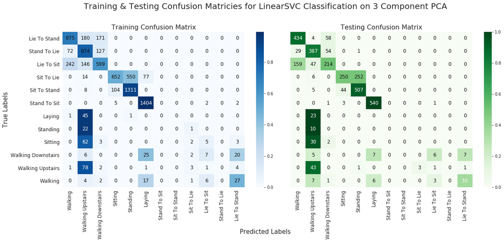

```python
title = 'Training & Testing Confusion Matricies for LinearSVC Classification on 3 Component PCA'
questionable_annot_colors = ['45', '23', '22', '62', '1311', '1404', '78', '540', '23', '10',
                             '507', '30', '434', '387', '43']
plot_confusion_matricies(pca_3_train_output_lsvc[2],
                         pca_3_test_output_lsvc[2],
                         title, questionable_annot_colors=questionable_annot_colors)
```

### Naive Bayes Classifier

```python
# NB classifier
clf_pca_3_nb = GaussianNB()

# Fit model to training data
# transform X_train with the PCA, reshapes the y_train dataframe into a 1D array
nb_train_time = train_classifier(clf_pca_3_nb, pca_3.transform(X_train), y_train.activity.values)
print (clf_pca_3_nb)
```

```
Training GaussianNB...
Done!
Training time (secs): 0.006
GaussianNB(priors=None, var_smoothing=1e-09)
```

```python
# Training metrics for NB Classifier
pca_3_train_output_nb = predict_labels(clf_pca_3_nb, pca_3.transform(X_train), y_train)
print ("Accuracy score for training set: {}".format(pca_3_train_output_nb[0]))
print ("F1 score for training set:       {}".format(pca_3_train_output_nb[1]))

# whitespace
print('')
print('')

# Testing metics for NB Classifier
pca_3_test_output_nb = predict_labels(clf_pca_3_nb, pca_3.transform(X_test), y_test, False)
print ("Accuracy score for Testing set: {:.10f}".format(pca_3_test_output_nb[0]))
print ("F1 score for Testing set:       {:.10f}".format(pca_3_test_output_nb[1]))
```

```
Predicting labels for Training Set using GaussianNB...
Done!
Prediction time for Training Set (secs): 0.007
Accuracy score for training set: 0.7072228659714175
F1 score for training set:       0.7045466014241805


Predicting labels for Testing Set using GaussianNB...
Done!
Prediction time for Testing Set (secs): 0.004
Accuracy score for Testing set: 0.7074636306
F1 score for Testing set:       0.6990404042
```

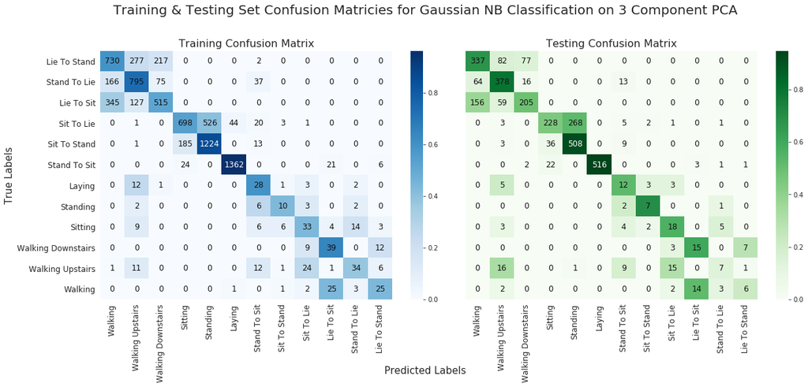

```python
title = 'Training & Testing Set Confusion Matricies for Gaussian NB Classification on 3 Component PCA'
questionable_annot_colors = ['1224', '1362', '508', '516']
plot_confusion_matricies(pca_3_train_output_nb[2],
                          pca_3_test_output_nb[2],
                          title, questionable_annot_colors)
```

### Support Vector Machine

```python
# SVM classifier
clf_pca_3_svc = SVC()

# Fit model to training data
# transform X_train with the PCA, reshapes the y_train dataframe into a 1D array
svc_train_time = train_classifier(clf_pca_3_svc, pca_3.transform(X_train), y_train.activity.values)
print (clf_pca_3_svc)
```

```
Training SVC...
```

```
Done!
Training time (secs): 0.573
SVC(C=1.0, cache_size=200, class_weight=None, coef0=0.0,
    decision_function_shape='ovr', degree=3, gamma='auto_deprecated',
    kernel='rbf', max_iter=-1, probability=False, random_state=None,
    shrinking=True, tol=0.001, verbose=False)
```

```python
pca_3_train_output_svc = predict_labels(clf_pca_3_svc, pca_3.transform(X_train), y_train)
print ("Accuracy score for training set: {}".format(pca_3_train_output_svc[0]))
print ("F1 score for training set:       {}".format(pca_3_train_output_svc[1]))

# whitespace
print('')
print('')

pca_3_test_output_svc = predict_labels(clf_pca_3_svc, pca_3.transform(X_test), y_test, False)
print ("Accuracy score for Testing set: {:.10f}".format(pca_3_test_output_svc[0]))
print ("F1 score for Testing set:       {:.10f}".format(pca_3_test_output_svc[1]))
```

```
Predicting labels for Training Set using SVC...
Done!
Prediction time for Training Set (secs): 1.190
Accuracy score for training set: 0.782412771984035
F1 score for training set:       0.7761482366075362


Predicting labels for Testing Set using SVC...
Done!
Prediction time for Testing Set (secs): 0.507
Accuracy score for Testing set: 0.7602783049
F1 score for Testing set:       0.7510807696
```

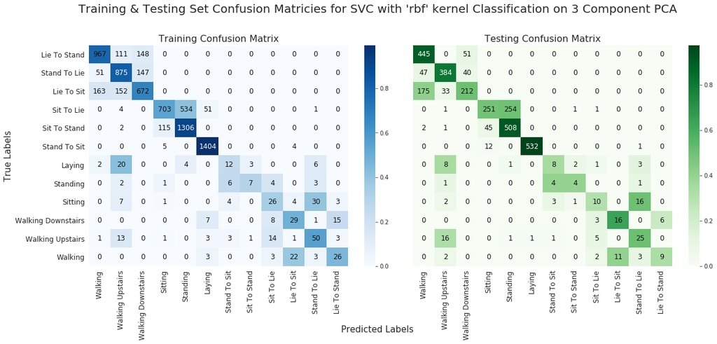

```python
title = "Training & Testing Set Confusion Matricies for SVC with 'rbf' kernel Classification on 3 Component PCA"
questionable_annot_colors = ['968', '875', '1306', '1404', '445', '508', '532', '384']
plot_confusion_matricies(pca_3_train_output_svc[2],
                         pca_3_test_output_svc[2],
                         title, questionable_annot_colors)
```

# Random Forest Classifier

```python
from sklearn.ensemble import RandomForestClassifier

# LinearSVC classifier
clf_pca_3_rf =  RandomForestClassifier()

# Fit model to training data
# transform X_train with the PCA, reshapes the y_train dataframe into a 1D array
rf_train_time = train_classifier(clf_pca_3_rf, pca_3.transform(X_train), y_train.activity.values)
print (clf_pca_3_rf)
```

```
Training RandomForestClassifier...
Done!
Training time (secs): 0.138
RandomForestClassifier(bootstrap=True, class_weight=None, criterion='gini',
                       max_depth=None, max_features='auto', max_leaf_nodes=None,
                       min_impurity_decrease=0.0, min_impurity_split=None,
                       min_samples_leaf=1, min_samples_split=2,
                       min_weight_fraction_leaf=0.0, n_estimators=10,
                       n_jobs=None, oob_score=False, random_state=None,
                       verbose=0, warm_start=False)
```

```python
# Training metrics Random Forest
pca_3_train_output_rf = predict_labels(clf_pca_3_rf, pca_3.transform(X_train), y_train)
print ("Accuracy score for training set: {}".format(pca_3_train_output_rf[0]))
print ("F1 score for training set:       {}".format(pca_3_train_output_rf[1]))

# whitespace
print('')
print('')

# Testing metrics Random Forest
pca_3_test_output_rf = predict_labels(clf_pca_3_rf, pca_3.transform(X_test), y_test, False)
print ("Accuracy score for Testing set: {:.10f}".format(pca_3_test_output_rf[0]))
print ("F1 score for Testing set:       {:.10f}".format(pca_3_test_output_rf[1]))
```

```
Predicting labels for Training Set using RandomForestClassifier...
Done!
Prediction time for Training Set (secs): 0.024
Accuracy score for training set: 0.9859662675421655
F1 score for training set:       0.9859466865045101


Predicting labels for Testing Set using RandomForestClassifier...
Done!
Prediction time for Testing Set (secs): 0.011
Accuracy score for Testing set: 0.7128399747
F1 score for Testing set:       0.7099053608
```

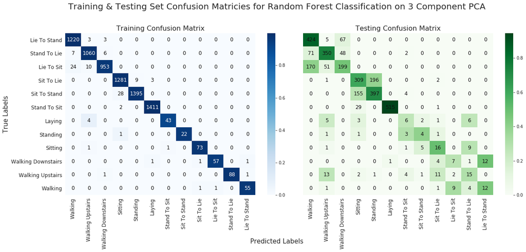

```python
# Plotting Random Forest CMs
title = 'Training & Testing Set Confusion Matricies for Random Forest Classification on 3 Component PCA'
questionable_annot_colors = ([str(pca_3_train_output_rf[2][x, x]) for x in range(12)] +
                            ['423', '513'])
plot_confusion_matricies(pca_3_train_output_rf[2],
                         pca_3_test_output_rf[2],
                         title, questionable_annot_colors)
```

### Associated Plots for Algorithm performance comparison on the 3 Component PCA data.

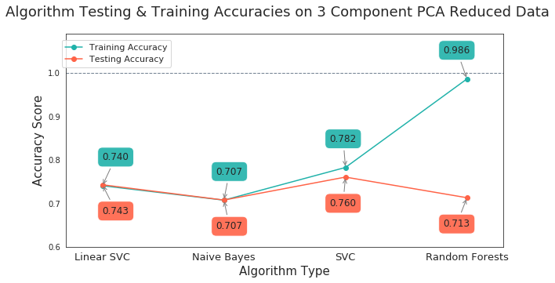

```python
# a plot of the different Testing & Training Accuracies
training_accuracies = [pca_3_train_output_lsvc[0],
                       pca_3_train_output_nb[0],
                       pca_3_train_output_svc[0],
                       pca_3_train_output_rf[0]]

testing_accuracies = [pca_3_test_output_lsvc[0],
                      pca_3_test_output_nb[0],
                      pca_3_test_output_svc[0],
                      pca_3_test_output_rf[0]]

algorithm_list = ['Linear SVC', 'Naive Bayes', 'SVC', 'Random Forests']

plt.figure(figsize=(10, 5))

plt.plot(training_accuracies, '-o', color='lightseagreen', label='Training Accuracy')
plt.plot(testing_accuracies, '-o', color='tomato', label='Testing Accuracy')

for i in range(len(testing_accuracies)):
    plt.annotate('{:.3f}'.format(testing_accuracies[i]),
            xy = (i, testing_accuracies[i]), xytext = (-10 * i , -40),
            textcoords = 'offset points', ha = 'left', va = 'bottom', fontsize=12,
            bbox = dict(boxstyle = 'round,pad=0.5', fc = 'tomato', alpha = 0.9),
            arrowprops = dict(arrowstyle = '->', connectionstyle = 'arc3, rad=0', linewidth=1, color='grey'))

for i in range(len(training_accuracies)):
    plt.annotate('{:.3f}'.format(training_accuracies[i]),
            xy = (i, training_accuracies[i]), xytext = (-10 * i , 30),
            textcoords = 'offset points', ha = 'left', va = 'bottom', fontsize=12,
            bbox = dict(boxstyle = 'round,pad=0.5', fc = 'lightseagreen', alpha = 0.9),
            arrowprops = dict(arrowstyle = '->', connectionstyle = 'arc3, rad=0', linewidth=1, color='grey'))

plt.axhline(1.0, color='slategrey', linestyle='dashed', linewidth=1)

plt.ylim(0.6, 1.09)
plt.ylabel('Accuracy Score', fontsize=15)

plt.xlim(-0.3, 3.3)
plt.xticks(range(4), algorithm_list, rotation=0, fontsize=13)
plt.xlabel('Algorithm Type', fontsize=15)

plt.suptitle('Algorithm Testing & Training Accuracies on 3 Component PCA Reduced Data', fontsize=18)
plt.legend(bbox_to_anchor=(0.25, 0.99), fontsize=11)

plt.show()
```

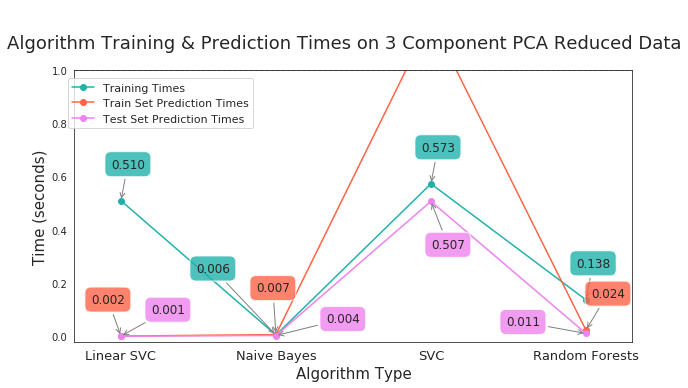

```python
# a plot of the different Testing & Training Times
training_times = [lsvc_train_time,
                  nb_train_time,
                  svc_train_time,
                  rf_train_time]

training_prediction_times = [pca_3_train_output_lsvc[3],
                             pca_3_train_output_nb[3],
                             pca_3_train_output_svc[3],
                             pca_3_train_output_rf[3]]

testing_prediction_times = [pca_3_test_output_lsvc[3],
                            pca_3_test_output_nb[3],
                            pca_3_test_output_svc[3],
                            pca_3_test_output_rf[3]]

plt.figure(figsize=(10, 5))

plt.plot(training_times, '-o', color='lightseagreen', label='Training Times')
plt.plot(training_prediction_times, '-o', color='tomato', label='Train Set Prediction Times')
plt.plot(testing_prediction_times, '-o', color='violet', label='Test Set Prediction Times')

def annotate_points(what_to_anno, locs, color):
    for i in range(len(what_to_anno)):
        plt.annotate('{:.3f}'.format(what_to_anno[i]),
                xy = (i, what_to_anno[i]), xytext = locs[i],
                textcoords = 'offset points', ha = 'left', va = 'bottom', fontsize=12,
                bbox = dict(boxstyle = 'round,pad=0.5', fc = color, alpha = 0.8),
                arrowprops = dict(arrowstyle = '->', connectionstyle = 'arc3, rad=0', linewidth=1, color='grey'))

annotate_points(training_times, [(-10, 30), (-80, 60), (-10, 30), (-10, 30)], 'lightseagreen')
annotate_points(training_prediction_times, [(-30, 30), (-20, 40), (-60, 0), (5, 30)], 'tomato')
annotate_points(testing_prediction_times, [(30, 20), (50, 10), (0, -50), (-80, 5)], 'violet')

plt.axhline(1.0, color='slategrey', linestyle='dashed', linewidth=1)

plt.ylim(-0.02, 1.0)
plt.ylabel('Time (seconds)', fontsize=15)

plt.xlim(-0.3, 3.3)
plt.xticks(range(4), algorithm_list, rotation=0, fontsize=13)
plt.xlabel('Algorithm Type', fontsize=15)

plt.suptitle('Algorithm Training & Prediction Times on 3 Component PCA Reduced Data', fontsize=18)
plt.legend(bbox_to_anchor=(0.33, 0.99), fontsize=11)

plt.show()
```

# ============================================================

# 38 component PCA

### Naive Bayes model on a PCA with 38 components (~90% of the variance captured)

```python
# PCA with 37 components
pca_38 = PCA(n_components = 38, whiten=True)

pca_38.fit(X_train)

# Print the components and the amount of variance in the data contained in each dimension
print(pca_38.components_)
print(pca_38.explained_variance_ratio_)
```

```
[[-1.52350723e-04  1.31333804e-04  2.26220409e-04 ... -3.66048330e-02
   2.66824414e-02  2.20740051e-02]
 [ 1.25587754e-03  2.70588959e-03  1.96011612e-03 ...  5.14345122e-02
  -2.05271477e-02 -2.52797908e-02]
 [ 6.95889893e-03 -4.84213130e-03 -3.60302323e-03 ...  2.80486575e-01
  -1.36272835e-01 -1.09363382e-01]
 ...
 [-3.01882279e-02  3.52136010e-02  2.53555463e-02 ... -1.37548602e-02
  -1.10200318e-03  3.61735792e-02]
 [-4.45915755e-02  4.01572717e-02  3.12591241e-02 ... -4.32423925e-02
  -2.31551127e-02 -7.64250668e-02]
 [ 1.44900344e-02 -4.47644943e-03 -5.52801054e-03 ...  2.94731884e-02
   4.99239506e-02  4.57195693e-02]]
[0.58635593 0.06425612 0.04489017 0.02116905 0.01636383 0.01363504
 0.01251664 0.01158892 0.00998506 0.00910735 0.0080903  0.00740391
 0.00707084 0.00587646 0.0053497  0.00512337 0.0048714  0.00476667
 0.00443129 0.00428027 0.00417815 0.0040916  0.00398404 0.00373089
 0.00351521 0.00333681 0.00308814 0.00298555 0.00291879 0.00288576
 0.00281253 0.00269822 0.00260152 0.0025347  0.00249553 0.00244417
 0.00238286 0.00225327]
```

```python
# Naive Bayes classifier
clf_pca_38_nb = GaussianNB()

# Fit model to training data
# transform X_train with the PCA, reshapes the y_train dataframe into a 1D array
pca_38_train_time_nb = train_classifier(clf_pca_38_nb, pca_38.transform(X_train), y_train.activity.values)
print (clf_pca_38_nb)
```

```
Training GaussianNB...
Done!
Training time (secs): 0.009
GaussianNB(priors=None, var_smoothing=1e-09)
```

```python
# Accuracy on the training set for a 38 component PCA
pca_38_train_output_nb = predict_labels(clf_pca_38_nb, pca_38.transform(X_train), y_train)
print ("Accuracy score for Training set: {:10f}".format(pca_38_train_output_nb[0]))
print ("F1 score for Training set:       {:10f}".format(pca_38_train_output_nb[1]))

# whitespace
print('')
print('')

# accuracy on the test set for a 38 component PCA
pca_38_test_output_nb = predict_labels(clf_pca_38_nb, pca_38.transform(X_test), y_test, False)
print ("Accuracy score for Testing set: {:.10f}".format(pca_38_test_output_nb[0]))
print ("F1 score for Testing set:       {:.10f}".format(pca_38_test_output_nb[1]))
```

```
Predicting labels for Training Set using GaussianNB...
Done!
Prediction time for Training Set (secs): 0.030
Accuracy score for Training set:   0.875113
F1 score for Training set:         0.875445


Predicting labels for Testing Set using GaussianNB...
Done!
Prediction time for Testing Set (secs): 0.012
Accuracy score for Testing set: 0.8608475648
F1 score for Testing set:       0.8585638315
```

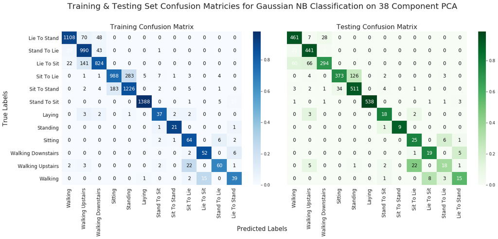

```python
# Plotting Naive Bayes 38 PCA CMs
title = 'Training & Testing Set Confusion Matricies for Gaussian NB Classification on 38 Component PCA'
questionable_annot_colors = ([str(pca_38_train_output_nb[2][x, x]) for x in range(12)] +
                             [str(pca_38_test_output_nb[2][x, x]) for x in range(12)])
plot_confusion_matricies(pca_38_train_output_nb[2],
                         pca_38_test_output_nb[2],
                         title, questionable_annot_colors)
```

## Gaussian NB model on the entire feature space

```python
# NB creation
clf = GaussianNB()

# Fit model to training data
train_times_nb = train_classifier(clf, X_train, y_train.activity.values) # reshapes the y_train dataframe into a 1D array
print (clf)  # you can inspect the learned model by printing it
```

```
Training GaussianNB...
Done!
Training time (secs): 0.080
GaussianNB(priors=None, var_smoothing=1e-09)
```

```python
nb_training_outputs = predict_labels(clf, X_train, y_train)
print ("Accuracy score for training set: {:.10f}".format(nb_training_outputs[0]))
print ("F1 score for the training set:   {:.10f}".format(nb_training_outputs[1]))

# whitespace
print('')
print('')

nb_test_outputs = predict_labels(clf, X_test, y_test, False)
print ("Accuracy score for test set: {:.10f}".format(nb_test_outputs[0]))
print ("F1 score for test set:       {:.10f}".format(nb_test_outputs[1]))
```

```
Predicting labels for Training Set using GaussianNB...
Done!
Prediction time for Training Set (secs): 0.420
Accuracy score for training set: 0.7126303592
F1 score for the training set:   0.7112609260


Predicting labels for Testing Set using GaussianNB...
Done!
Prediction time for Testing Set (secs): 0.146
Accuracy score for test set: 0.7473118280
F1 score for test set:       0.7427372716
```

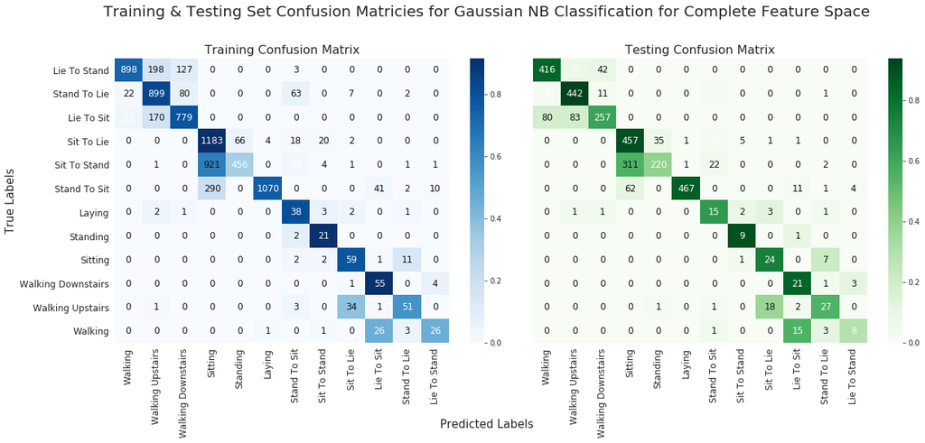

```python
# Plotting Naive Bayes 561 features
title = 'Training & Testing Set Confusion Matricies for Gaussian NB Classification for Complete Feature Space'
questionable_annot_colors = ([str(nb_training_outputs[2][x, x]) for x in range(12)] +
                             [str(nb_test_outputs[2][x, x]) for x in range(12)])
plot_confusion_matricies(nb_training_outputs[2],
                         nb_test_outputs[2],
                         title, questionable_annot_colors)
```

### SVC on a PCA with 38 components (~90% of the variance captured)

```python
# SVC classifier
clf_pca_38_svc =  SVC()

# Fit model to training data
# transform X_train with the PCA, reshapes the y_train dataframe into a 1D array
svc_train_time = train_classifier(clf_pca_38_svc, pca_38.transform(X_train), y_train.activity.values)
print (clf_pca_38_svc)
```

```
Training SVC...
```

```
Done!
Training time (secs): 2.272
SVC(C=1.0, cache_size=200, class_weight=None, coef0=0.0,
    decision_function_shape='ovr', degree=3, gamma='auto_deprecated',
    kernel='rbf', max_iter=-1, probability=False, random_state=None,
    shrinking=True, tol=0.001, verbose=False)
```

```python
# Training metrics SVC
pca_38_train_output_svc = predict_labels(clf_pca_38_svc, pca_38.transform(X_train), y_train)
print ("Accuracy score for training set: {}".format(pca_38_train_output_svc[0]))
print ("F1 score for training set:       {}".format(pca_38_train_output_svc[1]))

# whitespace
print('')
print('')

# Testing metrics SVC
pca_38_test_output_svc = predict_labels(clf_pca_38_svc, pca_38.transform(X_test), y_test, False)
print ("Accuracy score for Testing set: {:.10f}".format(pca_38_test_output_svc[0]))
print ("F1 score for Testing set:       {:.10f}".format(pca_38_test_output_svc[1]))
```

```
Predicting labels for Training Set using SVC...
Done!
Prediction time for Training Set (secs): 2.208
Accuracy score for training set: 0.9824900218874726
F1 score for training set:       0.982483455552408


Predicting labels for Testing Set using SVC...
Done!
Prediction time for Testing Set (secs): 0.924
Accuracy score for Testing set: 0.9165085389
F1 score for Testing set:       0.9157805704
```

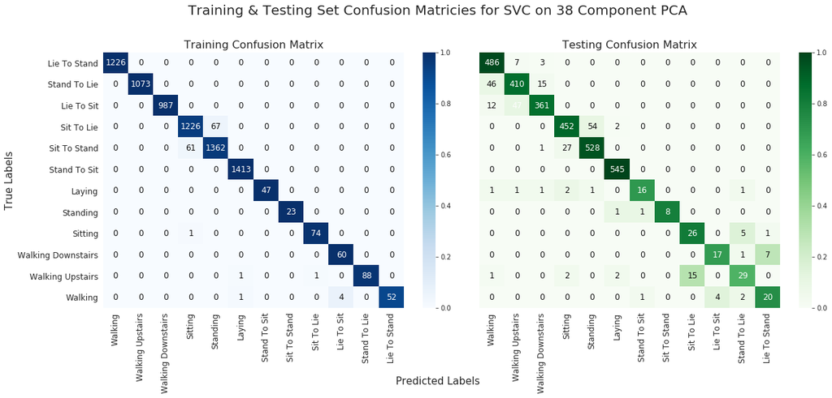

```python
# Plotting SVC Testing CMs
title = 'Training & Testing Set Confusion Matricies for SVC on 38 Component PCA'
questionable_annot_colors = ([str(pca_38_train_output_svc[2][x, x]) for x in range(12)] +
                             [str(pca_38_test_output_svc[2][x, x]) for x in range(12)])
plot_confusion_matricies(pca_38_train_output_svc[2],
                         pca_38_test_output_svc[2],
                         title, questionable_annot_colors)
```

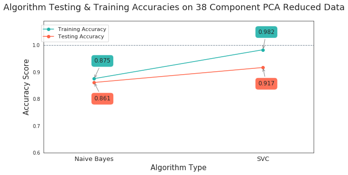

```python
# a plot of the different Testing & Training Accuracies
training_accuracies = [pca_38_train_output_nb[0],
                       pca_38_train_output_svc[0]]

testing_accuracies = [pca_38_test_output_nb[0],
                      pca_38_test_output_svc[0]]

algorithm_list = ['Naive Bayes', 'SVC']

plt.figure(figsize=(10, 5))

plt.plot(training_accuracies, '-o', color='lightseagreen', label='Training Accuracy')
plt.plot(testing_accuracies, '-o', color='tomato', label='Testing Accuracy')

for i in range(len(testing_accuracies)):
    plt.annotate('{:.3f}'.format(testing_accuracies[i]),
            xy = (i, testing_accuracies[i]), xytext = (-10 * i , -40),
            textcoords = 'offset points', ha = 'left', va = 'bottom', fontsize=12,
            bbox = dict(boxstyle = 'round,pad=0.5', fc = 'tomato', alpha = 0.9),
            arrowprops = dict(arrowstyle = '->', connectionstyle = 'arc3, rad=0', linewidth=1, color='grey'))

for i in range(len(training_accuracies)):
    plt.annotate('{:.3f}'.format(training_accuracies[i]),
            xy = (i, training_accuracies[i]), xytext = (-10 * i , 30),
            textcoords = 'offset points', ha = 'left', va = 'bottom', fontsize=12,
            bbox = dict(boxstyle = 'round,pad=0.5', fc = 'lightseagreen', alpha = 0.9),
            arrowprops = dict(arrowstyle = '->', connectionstyle = 'arc3, rad=0', linewidth=1, color='grey'))

plt.axhline(1.0, color='slategrey', linestyle='dashed', linewidth=1)

plt.ylim(0.6, 1.09)
plt.ylabel('Accuracy Score', fontsize=15)

plt.xlim(-0.3, 1.3)
plt.xticks(range(2), algorithm_list, rotation=0, fontsize=13)
plt.xlabel('Algorithm Type', fontsize=15)

plt.suptitle('Algorithm Testing & Training Accuracies on 38 Component PCA Reduced Data', fontsize=18)
plt.legend(bbox_to_anchor=(0.25, 0.99), fontsize=11)

plt.show()
```